# Chapter4: Latitude - Growth Data

### stan plots

```r
stan_trace(model.mat$fit)
```

```
## 'pars' not specified. Showing first 10 parameters by default.
```

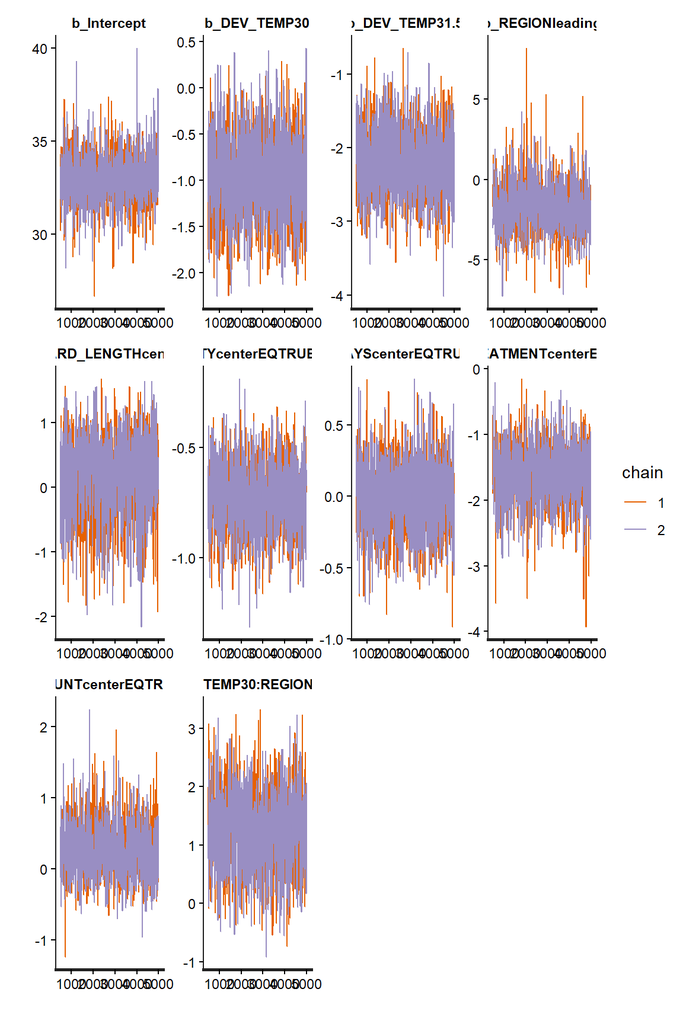

```r
stan_ac(model.mat$fit)
```

```
## 'pars' not specified. Showing first 10 parameters by default.
```

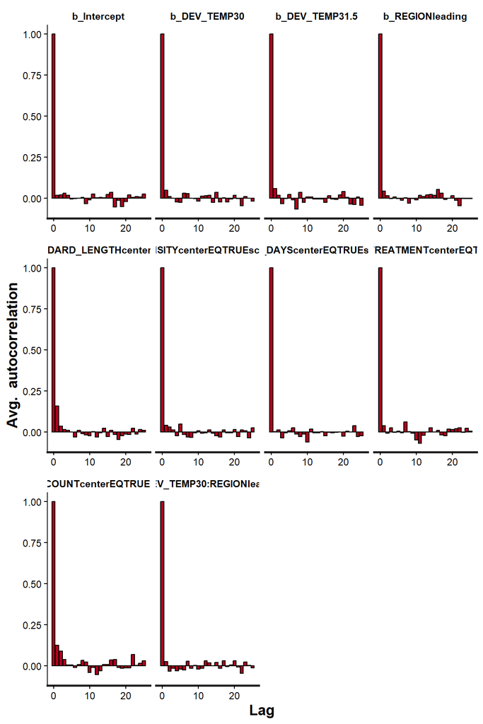

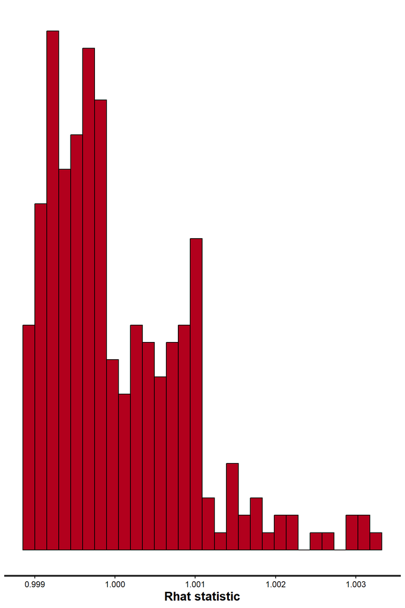

```r
stan_rhat(model.mat$fit)
```

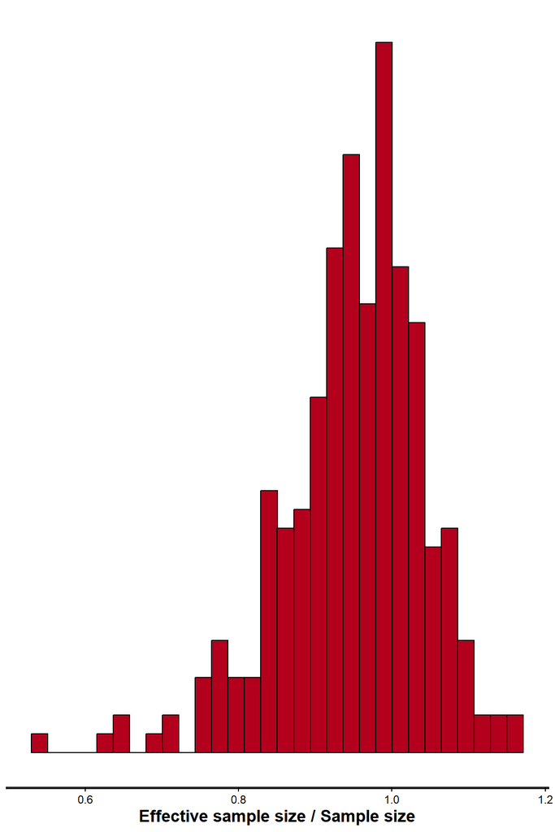

```r
stan_ess(model.mat$fit)
```

```r
stan_dens(model.mat$fit, separate_chains = TRUE)
```

```
## 'pars' not specified. Showing first 10 parameters by default.
```

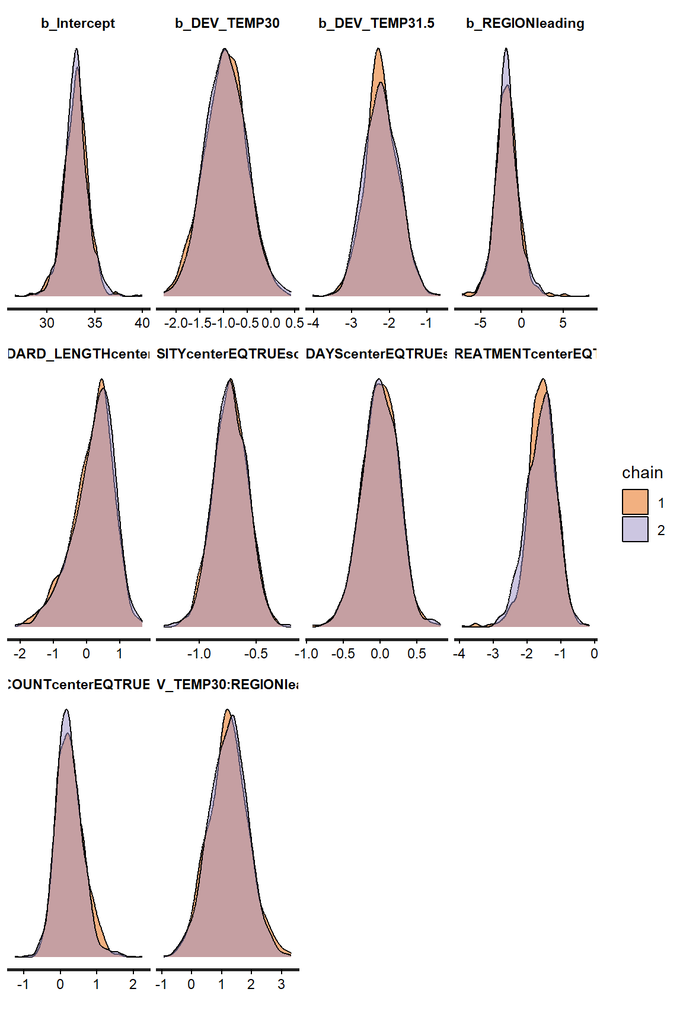

## Geographic model

### Priors

```r
model.geo.formula <- bf(LENGTH ~ DEV_TEMP*REGION +
                      scale(FEMALE_STANDARD_LENGTH, center=TRUE, scale=TRUE) +
                      scale(DENSITY, center=TRUE, scale=TRUE) +
                      scale(AGE_DAYS, center=TRUE, scale=TRUE)+
                      scale(FEMALE_LAT, center=TRUE, scale=TRUE)+
                      (1|TANK) +  (1|FEMALE),
              family=gaussian())
get_prior(model1.formula, data=growth3)
```

| prior | class | coef | group | resp | dpar | nlpar | lb | ub | tag | source |
| --- | --- | --- | --- | --- | --- | --- | --- | --- | --- | --- |
|  | b |  |  |  |  |  |  |  |  | default |
|  | b | DEV_TEMP30 |  |  |  |  |  |  |  | default |
|  | b | DEV_TEMP30:REGIONleading |  |  |  |  |  |  |  | default |
|  | b | DEV_TEMP31.5 |  |  |  |  |  |  |  | default |
|  | b | DEV_TEMP31.5:REGIONleading |  |  |  |  |  |  |  | default |
|  | b | REGIONleading |  |  |  |  |  |  |  | default |
|  | b | scaleAGE_DAYScenterEQTRUEscaleEQTRUE |  |  |  |  |  |  |  | default |
|  | b | scaleDENSITYcenterEQTRUEscaleEQTRUE |  |  |  |  |  |  |  | default |
|  | b | scaleFEMALE_STANDARD_LENGTHcenterEQTRUEscaleEQTRUE |  |  |  |  |  |  |  | default |
| student_t(3, 31.4, 3.8) | Intercept |  |  |  |  |  |  |  |  | default |

[output cut: 6 more lines]

```r
growth.priors <- prior(normal(31.4, 1.5), class="Intercept") +
  prior(normal(0, 1.5), class="b") +
  prior(student_t(3, 0, 4.4), class = "sigma")
```

```r
model.geo <- brm(model.geo.formula,
              data = growth3,
              warmup = 500,
              iter = 5000,
              seed=123,
              cores=2,
              save_pars = save_pars(all=TRUE),
              chains = 2,
              thin = 5,
              control = list(adapt_delta=0.95))
prior_summary(model.geo)
```

| prior | class | coef | group | resp | dpar | nlpar | lb | ub | source |
| --- | --- | --- | --- | --- | --- | --- | --- | --- | --- |
|  | b |  |  |  |  |  |  |  | default |
|  | b | DEV_TEMP30 |  |  |  |  |  |  | default |
|  | b | DEV_TEMP30:REGIONleading |  |  |  |  |  |  | default |
|  | b | DEV_TEMP31.5 |  |  |  |  |  |  | default |
|  | b | DEV_TEMP31.5:REGIONleading |  |  |  |  |  |  | default |
|  | b | REGIONleading |  |  |  |  |  |  | default |
|  | b | scaleAGE_DAYScenterEQTRUEscaleEQTRUE |  |  |  |  |  |  | default |
|  | b | scaleDENSITYcenterEQTRUEscaleEQTRUE |  |  |  |  |  |  | default |
|  | b | scaleFEMALE_LATcenterEQTRUEscaleEQTRUE |  |  |  |  |  |  | default |
|  | b | scaleFEMALE_STANDARD_LENGTHcenterEQTRUEscaleEQTRUE |  |  |  |  |  |  | default |

[output cut: 13 more lines]

```r
saveRDS(model.geo, file="./01.growth_data_analysis_files/model.geographic.length.RDS")
```

### stan plots

```r
stan_trace(model.geo$fit)
```

```
## 'pars' not specified. Showing first 10 parameters by default.
```

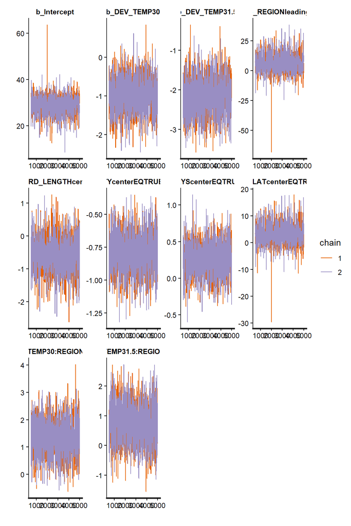

```r
stan_ac(model.geo$fit)
```

```
## 'pars' not specified. Showing first 10 parameters by default.
```

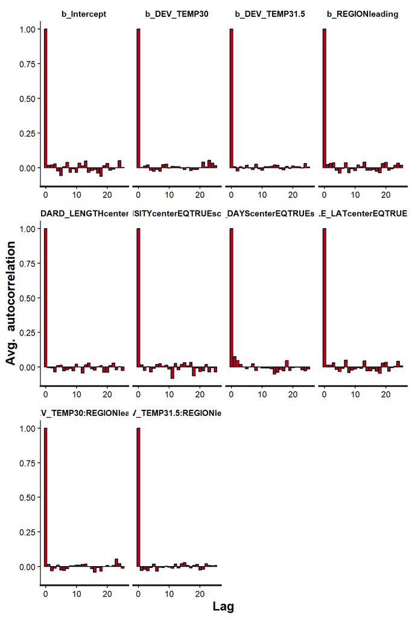

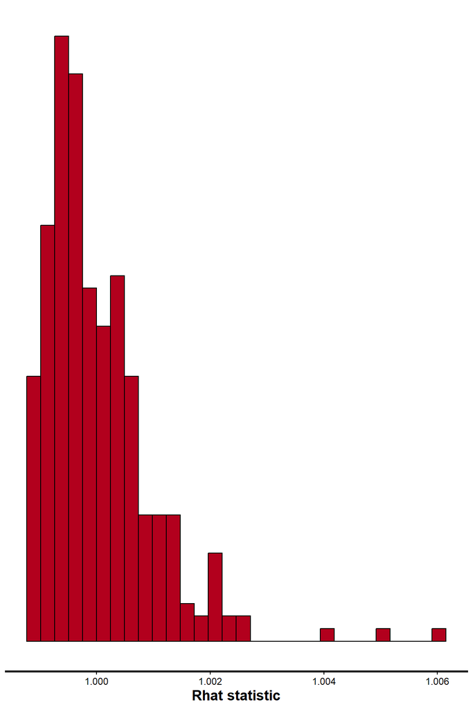

```r
stan_rhat(model.geo$fit)
```

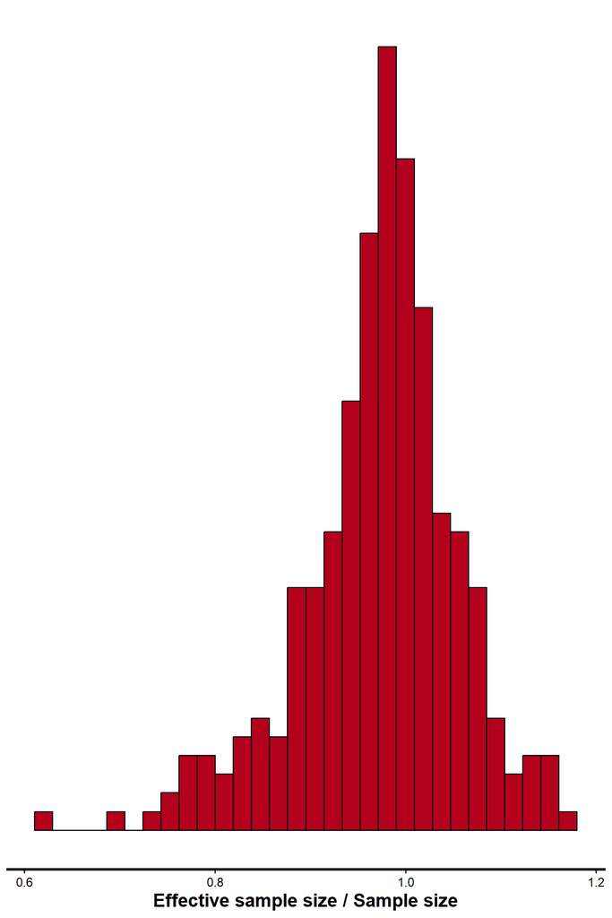

```r
stan_ess(model.geo$fit)
```

```r
stan_dens(model.geo$fit, separate_chains = TRUE)
```

```
## 'pars' not specified. Showing first 10 parameters by default.
```

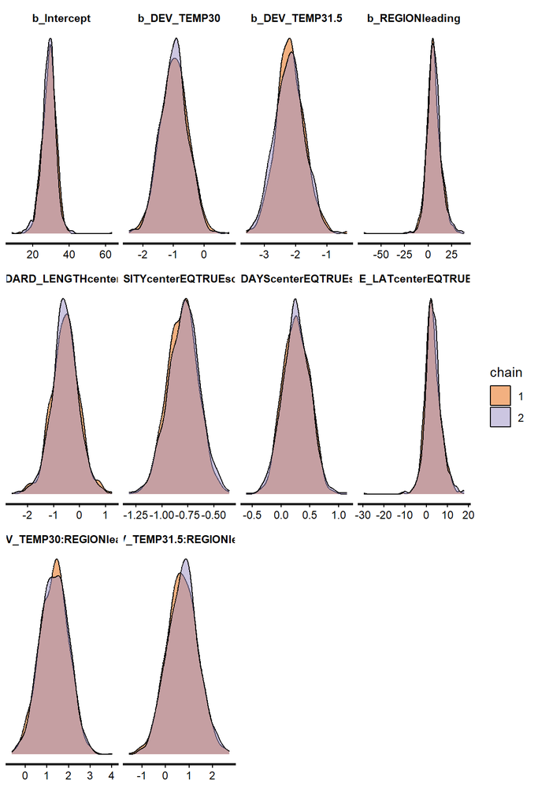

# Model Comparisons

The **model.mat** model will not be included in the comparison because the additional covariates within the model did not seem to explain a suitable amount of varirance in the model, ALSO, because there were more *’NA’s* in the these added covariates the observation sizes within the models were different meaning the models cannot be compared against each other using standard model comparison tools.

## LOO

```r
LOO(model1, model.geo)
```

```
## Output of model 'model1':
##
## Computed from 1800 by 1961 log-likelihood matrix.
##
##          Estimate   SE
## elpd_loo  -5322.7 40.6
## p_loo        84.2  3.5
## looic     10645.5 81.1
## ------
## MCSE of elpd_loo is NA.
## MCSE and ESS estimates assume MCMC draws (r_eff in [0.6, 1.2]).
##
## Pareto k diagnostic values:
##                           Count Pct.    Min. ESS
## (-Inf, 0.69]   (good)     1960  99.9%   603
##    (0.69, 1]   (bad)         1   0.1%   <NA>
##     (1, Inf)   (very bad)    0   0.0%   <NA>
## See help('pareto-k-diagnostic') for details.
##
## Output of model 'model.geo':
##
## Computed from 1800 by 1961 log-likelihood matrix.
##
##          Estimate   SE
## elpd_loo  -5318.4 40.5
## p_loo        79.8  3.4
## looic     10636.8 80.9
## ------
## MCSE of elpd_loo is 0.2.
## MCSE and ESS estimates assume MCMC draws (r_eff in [0.7, 1.2]).
##
## All Pareto k estimates are good (k < 0.69).
## See help('pareto-k-diagnostic') for details.
##
## Model comparisons:
##           elpd_diff se_diff
## model.geo  0.0       0.0
## model1    -4.3       2.9
```

Models show very little difference between each other, therefore we will continue with the most parismonous model - **model1**.

# Model validation

## DHARMa residuals

```r
pp_check(model1, type = 'dens_overlay')
```

```
## Using 10 posterior draws for ppc type 'dens_overlay' by default.
```

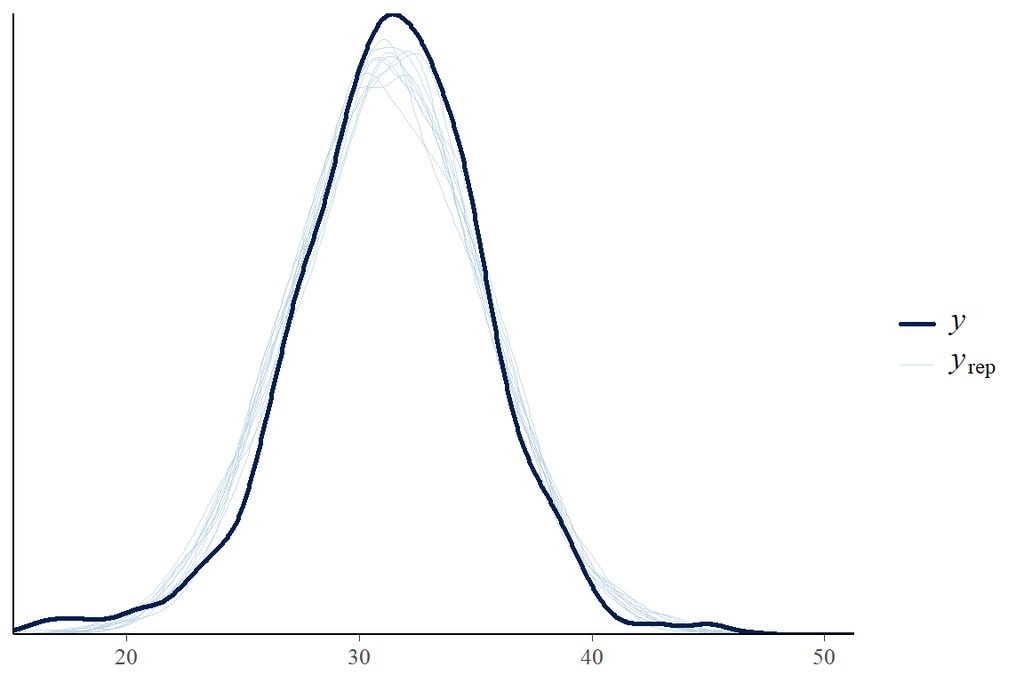

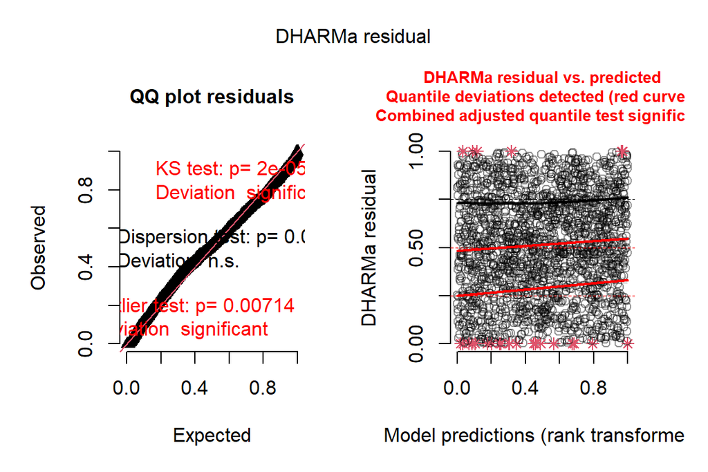

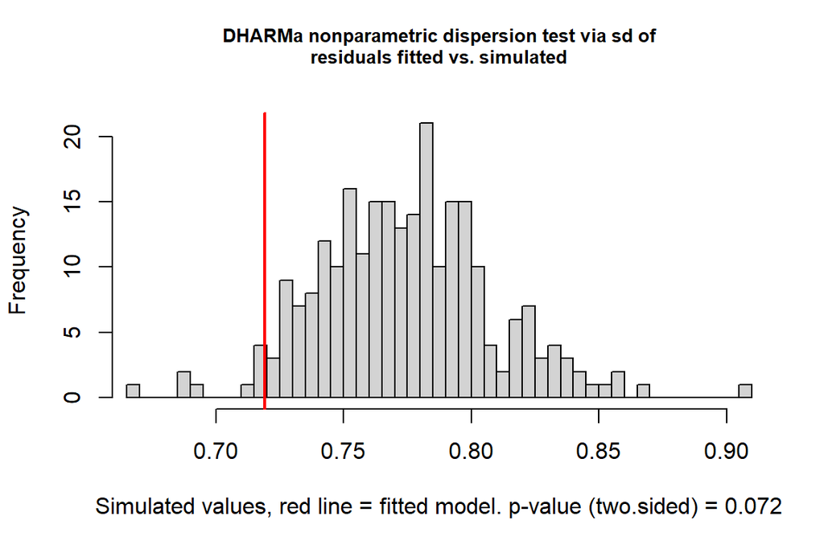

```
##
##  DHARMa nonparametric dispersion test via sd of residuals fitted vs.
##  simulated
##
## data:  simulationOutput
## dispersion = 0.9286, p-value = 0.072
## alternative hypothesis: two.sided
```

```r
preds <- posterior_predict(model1, ndraws=250, summary=FALSE)
model1.resids <- createDHARMa(simulatedResponse = t(preds),
                              observedResponse = na.omit(growth3$LENGTH),
                              fittedPredictedResponse = apply(preds, 2, median),
                              integerResponse = 'student')
plot(model1.resids); testDispersion(model1.resids)
```

I’m hesitant to remove further outliers. The mass of samples that sit above the main cluster don’t appear to be random, but rather belong to sets of populations, making me think that these data points are not outliers, but rather may be part of a geniunine pattern. The data set is rather large meaning some diagnositics need to be careful in intrepreting. For example, the KS test is used to detect deviations from the assumed distribution within the model. With such a large sample size small deviations can cause significant differences. If we look at our pp_check plot we can see that our observation and modelled distribution are actually very similar.The DHARMa checks also should that there are still outliers within the dataset and is likely upset about the cluster of points above the main cluster, but as previously stated these data points may be genuine. Once again due to the size of the dataset, this test may be overly sensitive. By looking at the residuals there is no clear pattern despite the DHARMa checks raising an alarm.

In the case with large datasets visual checks provide additional insight to statistical tests, and in this case out visual analysis seems to point in the direction of our model being appropriate.

# Partial effects plots

## conditional_effects

```
## Ignoring unknown labels:
## • fill : "NA"
## • colour : "NA"
## Ignoring unknown labels:
## • fill : "NA"
## • colour : "NA"
```

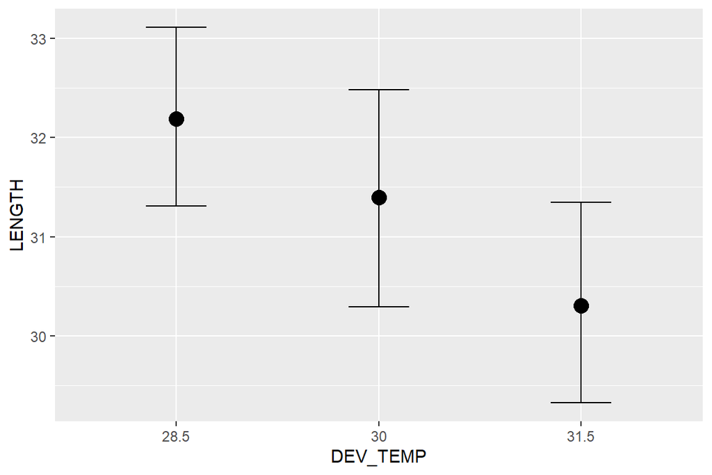

```
## Ignoring unknown labels:
## • fill : "NA"
## • colour : "NA"
## Ignoring unknown labels:
## • fill : "NA"
## • colour : "NA"
```

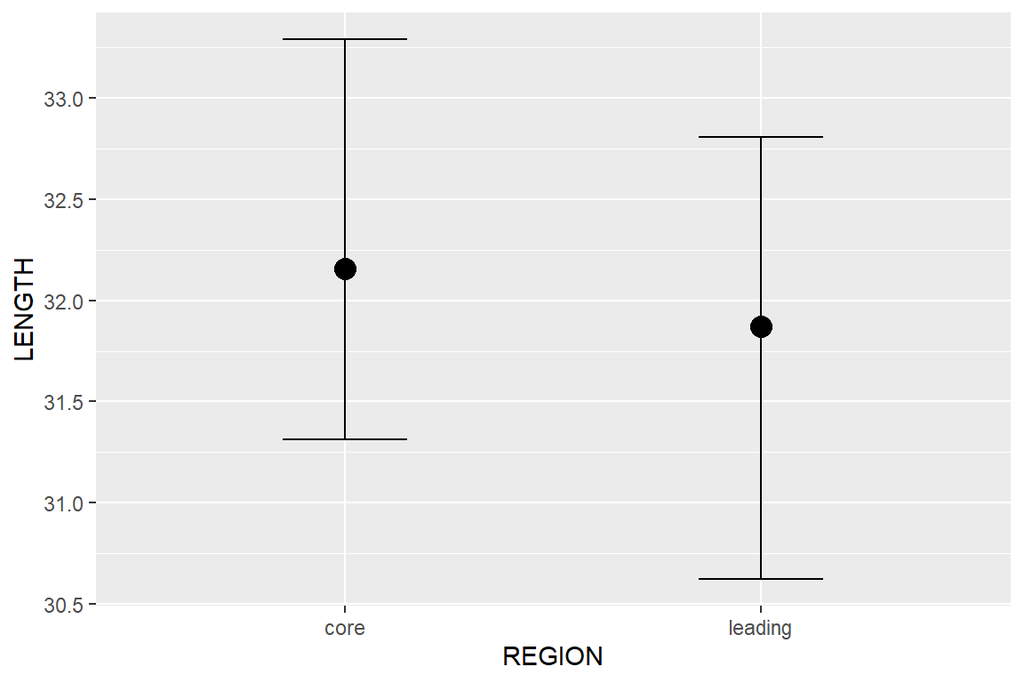

```
## Ignoring unknown labels:
## • colour : "NA"
## Ignoring unknown labels:
## • colour : "NA"
```

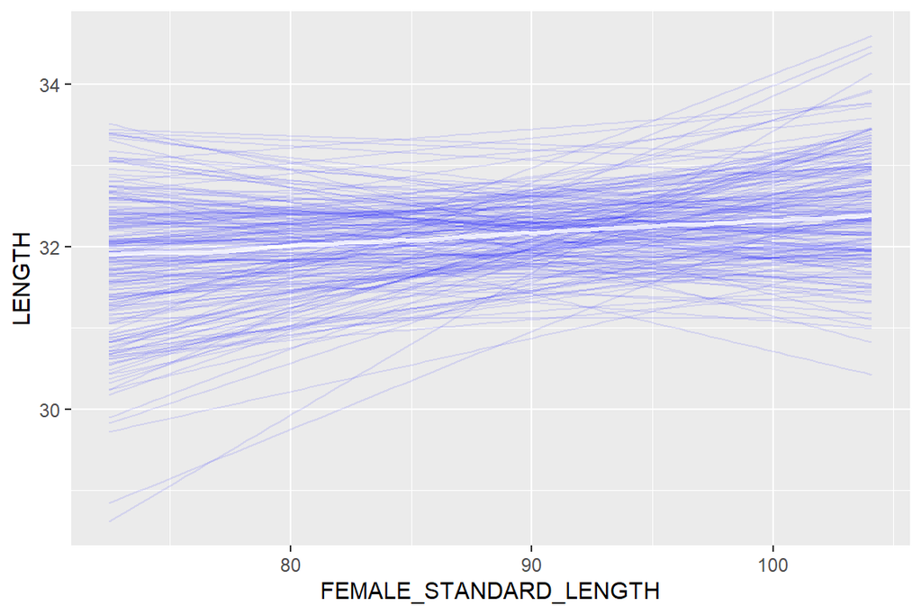

```
## Ignoring unknown labels:
## • colour : "NA"
## Ignoring unknown labels:
## • colour : "NA"
```

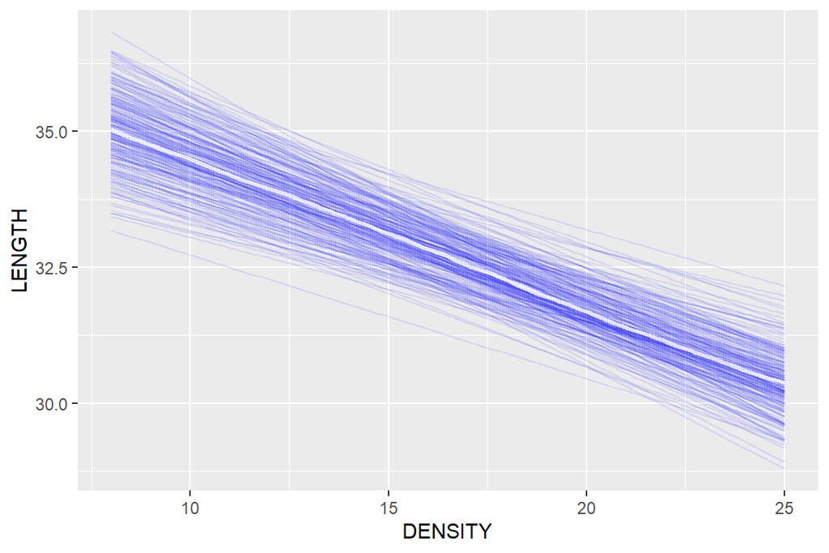

```
## Ignoring unknown labels:
## • colour : "NA"
## Ignoring unknown labels:
## • colour : "NA"
```

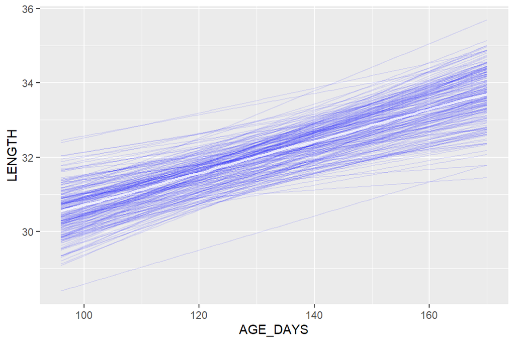

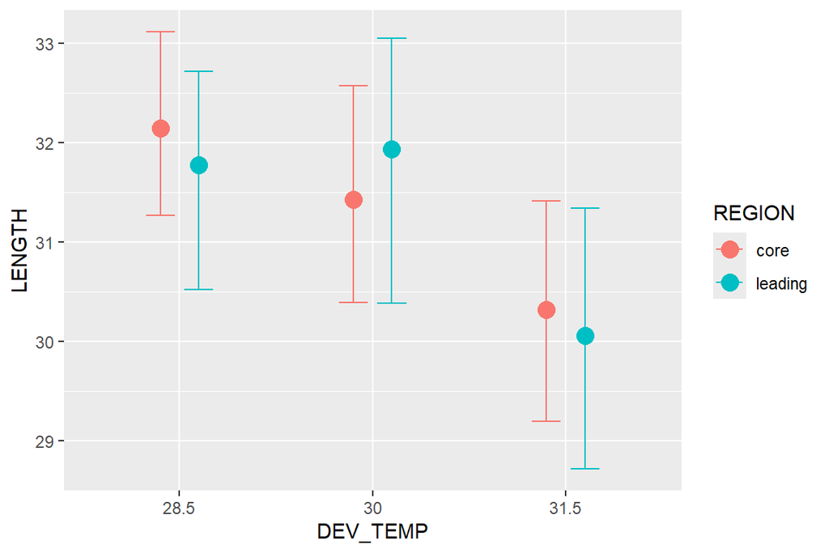

```r
model1 |>
  conditional_effects(spaghetti = TRUE, ndraws=200)
```

# Model investigation

## summary

```r
summary(model1)
```

```
##  Family: gaussian
##   Links: mu = identity
## Formula: LENGTH ~ DEV_TEMP * REGION + scale(FEMALE_STANDARD_LENGTH, center = TRUE, scale = TRUE) + scale(DENSITY, center = TRUE, scale = TRUE) + scale(AGE_DAYS, center = TRUE, scale = TRUE) + (1 | TANK) + (1 | FEMALE)
##    Data: growth3 (Number of observations: 1961)
##   Draws: 2 chains, each with iter = 5000; warmup = 500; thin = 5;
##          total post-warmup draws = 1800
##
## Multilevel Hyperparameters:
## ~FEMALE (Number of levels: 15)
##               Estimate Est.Error l-95% CI u-95% CI Rhat Bulk_ESS Tail_ESS
## sd(Intercept)     1.14      0.33     0.59     1.88 1.00     1349     1454
##
## ~TANK (Number of levels: 111)
##               Estimate Est.Error l-95% CI u-95% CI Rhat Bulk_ESS Tail_ESS
## sd(Intercept)     1.31      0.15     1.05     1.62 1.00     1523     1692
##
## Regression Coefficients:
##                                                    Estimate Est.Error l-95% CI
## Intercept                                             32.16      0.48    31.22
## DEV_TEMP30                                            -0.73      0.46    -1.64
## DEV_TEMP31.5                                          -1.81      0.46    -2.68
## REGIONleading                                         -0.40      0.72    -1.82
## scaleFEMALE_STANDARD_LENGTHcenterEQTRUEscaleEQTRUE     0.13      0.31    -0.46
## scaleDENSITYcenterEQTRUEscaleEQTRUE                   -0.74      0.15    -1.02
## scaleAGE_DAYScenterEQTRUEscaleEQTRUE                   0.60      0.18     0.26
## DEV_TEMP30:REGIONleading                               0.99      0.62    -0.17
## DEV_TEMP31.5:REGIONleading                             0.23      0.64    -1.02
##                                                    u-95% CI Rhat Bulk_ESS
## Intercept                                             33.14 1.00     1920
## DEV_TEMP30                                             0.14 1.00     1727
## DEV_TEMP31.5                                          -0.89 1.00     1697
## REGIONleading                                          1.03 1.00     1808
## scaleFEMALE_STANDARD_LENGTHcenterEQTRUEscaleEQTRUE     0.73 1.00     1717
## scaleDENSITYcenterEQTRUEscaleEQTRUE                   -0.44 1.00     1745
## scaleAGE_DAYScenterEQTRUEscaleEQTRUE                   0.93 1.00     1877
## DEV_TEMP30:REGIONleading                               2.24 1.00     1435
## DEV_TEMP31.5:REGIONleading                             1.44 1.00     1595
##                                                    Tail_ESS
## Intercept                                              1741
## DEV_TEMP30                                             1630
## DEV_TEMP31.5                                           1526
## REGIONleading                                          1826
## scaleFEMALE_STANDARD_LENGTHcenterEQTRUEscaleEQTRUE     1783
## scaleDENSITYcenterEQTRUEscaleEQTRUE                    1609
## scaleAGE_DAYScenterEQTRUEscaleEQTRUE                   1577
## DEV_TEMP30:REGIONleading                               1516
## DEV_TEMP31.5:REGIONleading                             1423
##
## Further Distributional Parameters:
##       Estimate Est.Error l-95% CI u-95% CI Rhat Bulk_ESS Tail_ESS
## sigma     3.57      0.06     3.46     3.69 1.00     1758     1490
##
## Draws were sampled using sampling(NUTS). For each parameter, Bulk_ESS
## and Tail_ESS are effective sample size measures, and Rhat is the potential
## scale reduction factor on split chains (at convergence, Rhat = 1).
```

## ANOVA

```r
model1 |> ref_grid() |> joint_tests()
```

|  | model term | df1 | df2 | F.ratio | Chisq | p.value |
| --- | --- | --- | --- | --- | --- | --- |
| 1 | DEV_TEMP | 2 | Inf | 12.318 | 24.636 | 4.471115e-06 |
| 3 | REGION | 1 | Inf | 0.000 | 0.000 | 9.923270e-01 |
| 2 | DEV_TEMP:REGION | 2 | Inf | 1.313 | 2.626 | 2.691392e-01 |

## R2

```r
model1 |> bayes_R2(summary = FALSE) |> median_hdci()
```

| y | ymin | ymax | .width | .point | .interval |
| --- | --- | --- | --- | --- | --- |
| 0.2548991 | 0.2223925 | 0.2812702 | 0.95 | median | hdci |

## tidyMCMC

```r
tidyMCMC(model1, estimate.method='median', conf.int=TRUE, conf.method='HPDinterval')
```

| term | estimate | std.error | conf.low | conf.high |
| --- | --- | --- | --- | --- |
| b_Intercept | 32.16006036 | 0.48456176 | 3.119899e+01 | 33.10877935 |
| b_DEV_TEMP30 | -0.73005590 | 0.45620747 | -1.666713e+00 | 0.10546348 |
| b_DEV_TEMP31.5 | -1.81392593 | 0.46392129 | -2.702772e+00 | -0.93357656 |
| b_REGIONleading | -0.40108530 | 0.71601302 | -1.751203e+00 | 1.08470527 |
| b_scaleFEMALE_STANDARD_LENGTHcenterEQTRUEscaleEQTRUE | 0.13155278 | 0.30578633 | -4.637140e-01 | 0.73388119 |
| b_scaleDENSITYcenterEQTRUEscaleEQTRUE | -0.74066639 | 0.15089555 | -1.031380e+00 | -0.46441383 |
| b_scaleAGE_DAYScenterEQTRUEscaleEQTRUE | 0.60105498 | 0.17553237 | 2.591999e-01 | 0.93211892 |
| b_DEV_TEMP30:REGIONleading | 0.99431768 | 0.62392774 | -1.749780e-01 | 2.23662728 |
| b_DEV_TEMP31.5:REGIONleading | 0.22785720 | 0.63932359 | -1.058685e+00 | 1.40580446 |
| sd_FEMALE__Intercept | 1.14301660 | 0.33227464 | 5.464036e-01 | 1.81403532 |

[output cut: 261 more lines]

## gather draws

```r
#model1 |> get_variables()
model1 |> gather_draws(`b_.*|sigma`, regex =TRUE) |>
  median_hdci()
```

| .variable | .value | .lower | .upper | .width | .point | .interval |
| --- | --- | --- | --- | --- | --- | --- |
| b_DEV_TEMP30 | -0.7222436 | -1.6355358 | 0.1411132 | 0.95 | median | hdci |
| b_DEV_TEMP30:REGIONleading | 0.9925274 | -0.1749780 | 2.2366273 | 0.95 | median | hdci |
| b_DEV_TEMP31.5 | -1.8153310 | -2.7027725 | -0.9335766 | 0.95 | median | hdci |
| b_DEV_TEMP31.5:REGIONleading | 0.2070721 | -1.0586846 | 1.4058045 | 0.95 | median | hdci |
| b_Intercept | 32.1648473 | 31.1989895 | 33.1087794 | 0.95 | median | hdci |
| b_REGIONleading | -0.4069060 | -1.6628839 | 1.1756290 | 0.95 | median | hdci |
| b_scaleAGE_DAYScenterEQTRUEscaleEQTRUE | 0.6084863 | 0.2770953 | 0.9536320 | 0.95 | median | hdci |
| b_scaleDENSITYcenterEQTRUEscaleEQTRUE | -0.7411733 | -1.0313798 | -0.4644138 | 0.95 | median | hdci |
| b_scaleFEMALE_STANDARD_LENGTHcenterEQTRUEscaleEQTRUE | 0.1244128 | -0.4476413 | 0.7515661 | 0.95 | median | hdci |
| sigma | 3.5709275 | 3.4629756 | 3.6855508 | 0.95 | median | hdci |

## bayesplot

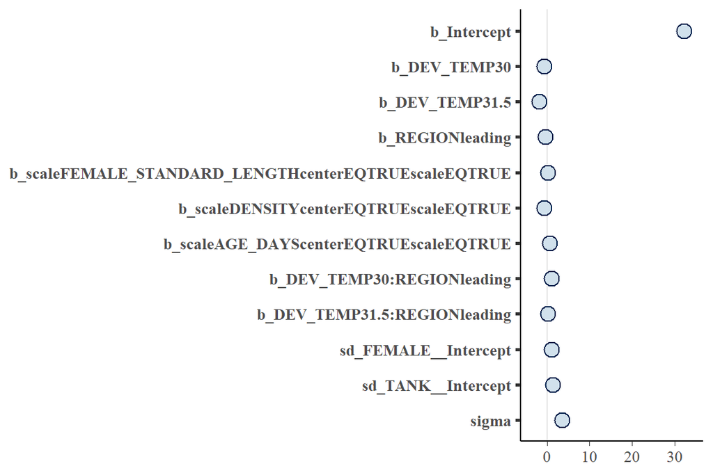

```r
model1 |> mcmc_plot(type='intervals')
```

## emmeans - pariwise

```r
out <- model1 |> emmeans(pairwise ~ REGION*DEV_TEMP, type="response")
out$emmeans |>
  as.data.frame() |>
  dplyr::mutate(across(where(is.numeric), ~ formatC(.x, digits = 2, format = "f")))
```

|  | REGION | DEV_TEMP | emmean | lower.HPD | upper.HPD |
| --- | --- | --- | --- | --- | --- |
| 1 | core | 28.5 | 32.16 | 31.20 | 33.11 |
| 2 | leading | 28.5 | 31.75 | 30.62 | 32.87 |
| 3 | core | 30 | 31.44 | 30.40 | 32.46 |
| 4 | leading | 30 | 32.01 | 30.76 | 33.15 |
| 5 | core | 31.5 | 30.34 | 29.28 | 31.35 |
| 6 | leading | 31.5 | 30.16 | 28.91 | 31.40 |

```r
model1 |> emmeans(pairwise ~ REGION*DEV_TEMP, type="response") |> regrid() |> pairs(by="DEV_TEMP") |> summary()
```

|  | contrast | DEV_TEMP | estimate | lower.HPD | upper.HPD |
| --- | --- | --- | --- | --- | --- |
| 1 | core - leading | 28.5 | 0.4069060 | -1.084705 | 1.7512026 |
| 2 | core - leading | 30 | -0.6059544 | -2.009244 | 0.9492163 |
| 3 | core - leading | 31.5 | 0.1797574 | -1.325511 | 1.8518016 |

```r
model1 |> emmeans(pairwise ~ DEV_TEMP, type="response") |> regrid() |> summary()
```

```
## NOTE: Results may be misleading due to involvement in interactions
```

|  | DEV_TEMP | emmean | lower.HPD | upper.HPD |
| --- | --- | --- | --- | --- |
| 1 | 28.5 | 31.95739 | 31.21088 | 32.72793 |
| 2 | 30 | 31.73096 | 30.90464 | 32.52560 |
| 3 | 31.5 | 30.25543 | 29.38949 | 31.05872 |

```r
model1 |> emmeans(pairwise ~ REGION*DEV_TEMP, type="response") |> regrid() |> pairs(by="REGION") |> summary()
```

|  | contrast | REGION | estimate | lower.HPD | upper.HPD |
| --- | --- | --- | --- | --- | --- |
| 1 | DEV_TEMP28.5 - DEV_TEMP30 | core | 0.7222436 | -0.1054635 | 1.6667135 |
| 2 | DEV_TEMP28.5 - DEV_TEMP31.5 | core | 1.8153310 | 0.9335766 | 2.7027725 |
| 3 | DEV_TEMP30 - DEV_TEMP31.5 | core | 1.1115592 | 0.1049469 | 2.0416164 |
| 4 | DEV_TEMP28.5 - DEV_TEMP30 | leading | -0.2580620 | -1.2372404 | 0.6533852 |
| 5 | DEV_TEMP28.5 - DEV_TEMP31.5 | leading | 1.5723256 | 0.6046002 | 2.5794524 |
| 6 | DEV_TEMP30 - DEV_TEMP31.5 | leading | 1.8460002 | 0.8889276 | 2.8803787 |

```r
model1 |> emmeans(pairwise ~ DEV_TEMP, type="response") |> regrid() |> pairs() |> summary()
```

```
## NOTE: Results may be misleading due to involvement in interactions
```

|  | contrast | estimate | lower.HPD | upper.HPD |
| --- | --- | --- | --- | --- |
| 1 | DEV_TEMP28.5 - DEV_TEMP30 | 0.2300933 | -0.4138159 | 0.9523511 |
| 2 | DEV_TEMP28.5 - DEV_TEMP31.5 | 1.6956398 | 0.9771672 | 2.4063373 |
| 3 | DEV_TEMP30 - DEV_TEMP31.5 | 1.4717481 | 0.7841098 | 2.2387224 |

## probabilities

```r
mtsqst <- model1 |> emmeans(pairwise ~ REGION*DEV_TEMP)
mtsqrt2 <- mtsqst$contrasts |> gather_emmeans_draws()
mtsqrt2 %>% group_by(contrast) %>% dplyr::summarise(Prob = sum(.value>0)/n())
```

| contrast | Prob |
| --- | --- |
| core DEV_TEMP28.5 - core DEV_TEMP30 | 0.9544444 |
| core DEV_TEMP28.5 - core DEV_TEMP31.5 | 0.9994444 |
| core DEV_TEMP28.5 - leading DEV_TEMP28.5 | 0.7222222 |
| core DEV_TEMP28.5 - leading DEV_TEMP30 | 0.5783333 |
| core DEV_TEMP28.5 - leading DEV_TEMP31.5 | 0.9972222 |
| core DEV_TEMP30 - core DEV_TEMP31.5 | 0.9822222 |
| core DEV_TEMP30 - leading DEV_TEMP30 | 0.2161111 |
| core DEV_TEMP30 - leading DEV_TEMP31.5 | 0.9422222 |
| core DEV_TEMP31.5 - leading DEV_TEMP31.5 | 0.5977778 |
| leading DEV_TEMP28.5 - core DEV_TEMP30 | 0.6600000 |

[output cut: 5 more lines]

# summary figure

```r
var <- get_variables(model1)
var1 <- get_variables(model1)[c(1:4,8:9)]

int_draws_spread <- model1 |> spread_draws(!!!syms(var1))

int_draws_spread2 <- int_draws_spread |>
  gather_draws(b_Intercept, b_REGIONleading) |>
  left_join(int_draws_spread, by = c(".chain",".iteration",".draw"))


int_draws <- int_draws_spread2 |>
  mutate(x28.5 = case_when(`.variable` == 'b_Intercept' ~
                                 `.value`,
                               `.variable` != 'b_Intercept' ~
                                 `.value` + b_Intercept),

         x30 = case_when(`.variable` == 'b_Intercept' ~
                                 `.value` + b_DEV_TEMP30,
                             `.variable` == 'b_REGIONleading' ~
                                 `.value` + b_Intercept + b_DEV_TEMP30 + `b_DEV_TEMP30:REGIONleading`),

         x31.5 = case_when(`.variable` == 'b_Intercept' ~
                                 `.value` + b_DEV_TEMP31.5,
                             `.variable` == 'b_REGIONleading' ~
                                 `.value` + b_Intercept + b_DEV_TEMP31.5 + `b_DEV_TEMP31.5:REGIONleading`))

int_draws_plotting <- int_draws |>
  pivot_longer(cols = starts_with("x"),
               names_to = "DEV_TEMP",
               values_to = "LENGTH") |>
  transmute(LATITUDE = case_when(`.variable` == "b_Intercept" ~ "Low latitude",
                                 `.variable` == "b_REGIONleading" ~ "High latitude"),
            DEV_TEMP = case_when(DEV_TEMP == 'x28.5' ~ 'DEV_TEMP_28.5',
                                 DEV_TEMP == 'x30' ~ 'DEV_TEMP_30',
                                 DEV_TEMP == 'x31.5' ~ 'DEV_TEMP_31.5'),
            LENGTH = LENGTH,
            LATITUDE_B = LATITUDE,
            DEV_TEMP_B = DEV_TEMP,
            chain = `.chain`,
            iteration = `.iteration`,
            draw_n = `.draw`) |>
  unite("EXP_GROUP",LATITUDE_B, DEV_TEMP_B,sep="_") |>
  mutate(EXP_GROUP = as.factor(EXP_GROUP)) |>
  mutate(EXP_GROUP = factor(EXP_GROUP, levels=c("High latitude_DEV_TEMP_28.5","High latitude_DEV_TEMP_30", "High latitude_DEV_TEMP_31.5",
                                                "Low latitude_DEV_TEMP_28.5","Low latitude_DEV_TEMP_30", "Low latitude_DEV_TEMP_31.5")))
```

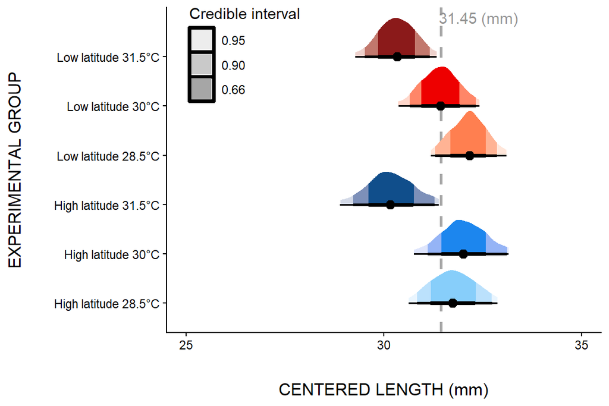

```r
length.plot <- int_draws_plotting |>
  ggplot(aes(x=EXP_GROUP, y=LENGTH)) +
  geom_hline(yintercept = median(int_draws_plotting$LENGTH), linetype="dashed", linewidth=1, color="grey58", alpha=0.8) +
  ggdist::stat_halfeye(aes(fill = EXP_GROUP, fill_ramp = after_stat(level)),
               point_interval = median_hdci,
               .width = c(.66, .90, .95)) +
  scale_fill_ramp_discrete(na.translate=FALSE,
                           labels =c("0.95","0.90","0.66"),
                           name = "Credible interval") +
  scale_fill_manual(values = c("lightskyblue" ,"dodgerblue2", "dodgerblue4","coral", "red2","firebrick4"))+
  scale_y_continuous(limits=c(25,35), breaks = seq(25,35, 5))+
  ylab("CENTERED LENGTH (mm)") + xlab("EXPERIMENTAL GROUP") +
  scale_x_discrete(labels = c("Low latitude_DEV_TEMP_28.5" = paste0("Low latitude 28.5","\u00B0","C"),
                              "Low latitude_DEV_TEMP_30" = paste0("Low latitude 30","\u00B0","C"),
                              "Low latitude_DEV_TEMP_31.5" = paste0("Low latitude 31.5","\u00B0","C"),
                              "High latitude_DEV_TEMP_28.5" = paste0("High latitude 28.5","\u00B0","C"),
                              "High latitude_DEV_TEMP_30" = paste0("High latitude 30","\u00B0","C"),
                              "High latitude_DEV_TEMP_31.5" = paste0("High latitude 31.5","\u00B0","C"))) +
  annotate("text", x=6.8,y=32.4, label = paste0(round(median(int_draws_plotting$LENGTH), 2)," (mm)"), color="grey58") +
  coord_flip() +
  theme_classic() +
  guides(fill = "none") +
  theme(legend.position = c(.18,.86),
        axis.title.y = element_text(margin = margin(r =0.3, unit = "in"), size = 12),
        axis.title.x = element_text(margin = margin(t = 0.3, unit="in"), size =12),
        legend.key = element_rect(color="black", size=1.25)); length.plot
```

```r
#ggsave(file="./figures/length.plot.svg",  plot=length.plot, width=8, height=5, units = "in", dpi=300)
#ggsave(file="./figures/length.plot.pdf",  plot=length.plot, width=8, height=5, units = "in", dpi=300)
```

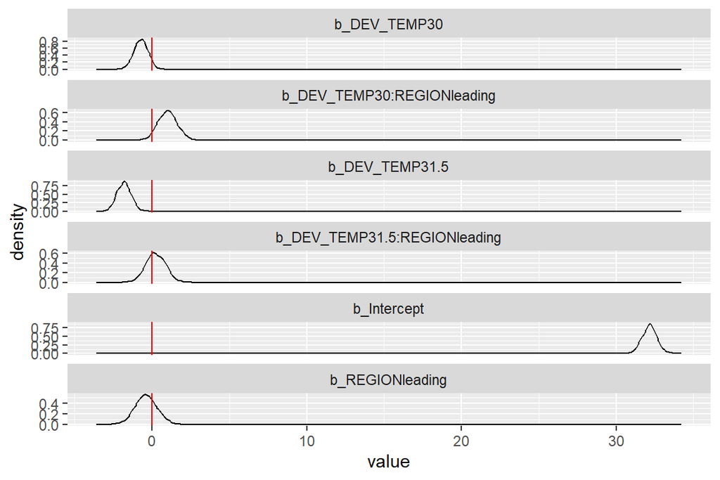

```r
int_draws_spread %>%
  pivot_longer(everything(), names_to = 'var', values_to = 'value') %>%
  dplyr::filter(!var %in% c('.chain', '.draw', '.iteration')) %>%
  ggplot(aes(x = value)) +
  geom_density() +
  facet_wrap(~ var, ncol = 1, scales = 'free_y') +
  geom_vline(xintercept=0, color="red")
```

```r
growth_age_plot <- ggplot(growth3, aes(x=REGION, y=AGE_DAYS, fill=REGION, color=REGION)) +
  stat_halfeye(adjust =0.5,
               justification =-0.2,
               .width =0,
               point_color=NA) +
  geom_boxplot(width =0.12,
               outlier.color =NA,
               alpha =0.5) +
  stat_dots(side = "left",
            justification = 1.1,
            binwidth = NA) +
  scale_fill_manual(values = c("firebrick4","dodgerblue4"))+
  scale_color_manual(values = c("firebrick4","dodgerblue4"))+
  scale_x_discrete(labels =c("leading" = "High",
                             "core" = "Low")) +
  theme_classic() +
  labs(
    x = "LATITUDE",
    y = "AGE (DAYS)"
  ) +
  coord_flip() +
  theme(legend.position = "none")

#ggsave(file="./figures/length.age.plot.svg",  plot=growth_age_plot, width=8, height=5, units = "in", dpi=300)
#ggsave(file="./figures/length.age.plot.pdf",  plot=growth_age_plot, width=8, height=5, units = "in", dpi=300)
```